# Lab 13 - Chi square, ANOVA, & correlation

Ramin Jabbarialghanab

November 21, 2017

Complete the following exercises below and include all code used to find the answers. Knit together the PDF document and commit both the Lab 13 RMD file and the PDF document to Git. Push the changes to GitHub so both documents are visible in your public GitHub repository.

**1. Select two categorical variables from your dataset whose association you’re interested in and conduct a chi-square test.** *If you only have continuous variables you will need to create categorical versions of these variables to make this work. You can do this using the `cut` function in mutate to add a new, categorical version of your variable to your dataset.*

```r
# chi squrate  for gender and value_cut
install.packages("ggplot2")
install.packages("readxl")
library(tidyverse)
library(foreign)
library(ggplot2)
library(readxl)
joint_unemployment_total <- read_excel("~/Desktop/Autumn 2017/Statistics 321/unemployment rate/joint_unemployment_total.xlsx")
Chi <- joint_unemployment_total[,-2]
joint_unemployment_total <- joint_unemployment_total %>%
  mutate(value_cut = cut(value, 4))
Chi <- subset(joint_unemployment_total, select = c(gender, value_cut))
chisq.test(table(Chi))
```

```
##
##  Pearson's Chi-squared test
##
## data:  table(Chi)
## X-squared = 18, df = 3, p-value = 0.0004398
```

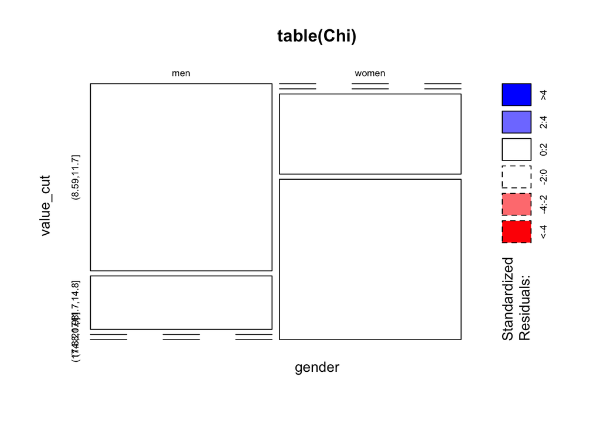

```r
#creating mosaicplot
mosaicplot(table(Chi),
           shade = TRUE)
```

1. Describe any modifications made to your data for the chi-square test and the composition of the variables used in the test (e.g., study time is measured using a three-category ordinal variable with categories indicating infrequent studying, medium studying, and frequent studying).

2. Does there appear to be an association between your two variables? Explain your reasoning.

3. What are the degrees of freedom for this test and how is this calculated?

For two-way chi-square, degrees of freedom can be calculated with this formula: (df)=(R−1)(C−1) For my data the degree of freedom is (df) = (4-1)(2-1) = 3

4. What if the critical value for the test statistic? What is the obtained value for the test statistic?

The critical value for degre of freedom of 3 and Alpha level of 5% is 7.815. The obtained valued for test statistic is 18.

5. How do you interpret the results of this test and the implications for your theoretical arguments about these two variables?

Since the test staristic is greater than critical value, I reject the null hyphoesis that there is no difference between unemployment rate of men and unemployment rate of women.

**2. Select one continuous variable and one categorical variable from your dataset whose association you’re interested in exploring.** *Again, note that you’ll need to create a categorical version of your independent variable to make this work.*

```r
# Creating ANOVA to see the result
results <- aov(value ~ gender, data = joint_unemployment_total)
summary(results)
```

```
##             Df Sum Sq Mean Sq F value   Pr(>F)
## gender       1  328.5   328.5   119.2 7.98e-09 ***
## Residuals   16   44.1     2.8
## ---
## Signif. codes:  0 '***' 0.001 '**' 0.01 '*' 0.05 '.' 0.1 ' ' 1
```

1. Describe any modifications made to your data for the ANOVA test and the composition of the variables used in the test (e.g., college rank is measured using a four-category variable with values indicating freshman, sophomore, junior, and senior class).

For ANOVA test have had one categorical variable of gender, and one continuos variable of “value” which reflect unemployment rate. So, there is no need for modification.

2. What are the degrees of freedom (both types) for this test and how are they calculated?

df1=dfbetween= J−1= 2−1= 1 df2=dfwithin=N−J=18 −2 =16 F(critical) with alpha .05 = 4.49

3. What is the obtained value of the test statistic?

F-statistic is 119.2 and P value equal to 7.98e-09.

```r
# Bivariate contingency table
library(gmodels)
CrossTable(table(Chi),
           digits = 2,
           prop.r = TRUE,
           prop.c = FALSE,
           prop.t = FALSE,
           prop.chisq = FALSE)
```

```
##
##
##    Cell Contents
## |-------------------------|
## |                       N |
## |           N / Row Total |
## |-------------------------|
##
##
## Total Observations in Table:  18
##
##
##              | value_cut
##       gender | (8.59,11.7] | (11.7,14.8] | (14.8,17.8] | (17.8,20.9] |   Row Total |
## -------------|-------------|-------------|-------------|-------------|-------------|
##          men |           7 |           2 |           0 |           0 |           9 |
##              |        0.78 |        0.22 |        0.00 |        0.00 |        0.50 |
## -------------|-------------|-------------|-------------|-------------|-------------|
##        women |           0 |           0 |           3 |           6 |           9 |
##              |        0.00 |        0.00 |        0.33 |        0.67 |        0.50 |
## -------------|-------------|-------------|-------------|-------------|-------------|
## Column Total |           7 |           2 |           3 |           6 |          18 |
## -------------|-------------|-------------|-------------|-------------|-------------|
##
##
```

4. What do the resuts tell you about the association between these two variables? What does this mean for your theoretical arguments about these variables?

**3. Select two continuous variables from your dataset whos association you’re interested in exploring.**

I selected gender and value ariables to look at the association. Since gender is categorical, by mutate function, the column gender_num is created as a continous variable.

1. What is the correlation between these two variables?

```r
# changing categorical gender variable to a continoues variable
joint_unemployment_total
```

```
## # A tibble: 18 x 4
##    gender  year value   value_cut
##     <chr> <dbl> <dbl>      <fctr>
##  1    men  2001  13.2 (11.7,14.8]
##  2  women  2001  19.9 (17.8,20.9]
##  3    men  2006  10.0 (8.59,11.7]
##  4  women  2006  16.2 (14.8,17.8]
##  5    men  2008   9.1 (8.59,11.7]
##  6  women  2008  16.7 (14.8,17.8]
##  7    men  2009  10.8 (8.59,11.7]
##  8  women  2009  16.8 (14.8,17.8]
##  9    men  2010  11.9 (11.7,14.8]
## 10  women  2010  20.5 (17.8,20.9]
## 11    men  2011  10.5 (8.59,11.7]
## 12  women  2011  20.9 (17.8,20.9]
## 13    men  2012  10.4 (8.59,11.7]
## 14  women  2012  19.7 (17.8,20.9]
## 15    men  2013   8.6 (8.59,11.7]
## 16  women  2013  19.8 (17.8,20.9]
## 17    men  2014   8.8 (8.59,11.7]
## 18  women  2014  19.7 (17.8,20.9]
```

```r
joint_unemployment_total <- joint_unemployment_total %>%
  mutate(gender_num = ifelse(test = gender == "men",
                             yes = 0,
                             no = 1))
```

```r
#Creating correlation between value and gender_num
cor(joint_unemployment_total$value, joint_unemployment_total$gender_num)
```

```
## [1] 0.9389779
```

2. Create a scatterplot of the variables you selected. Does the correlation coefficient accurately represent the relationship between these two variables? Why or why not?

```r
#creating scatterplot
install.packages("ggplot2")
library(ggplot2)
scatterplot(value ~ gender_num, data=joint_unemployment_total)
```

[output not shown]

3. Create a correlation matrix of your data using the `ggcorr` function from the `GGally` package. Be sure to label each cell with the correlation coefficient.

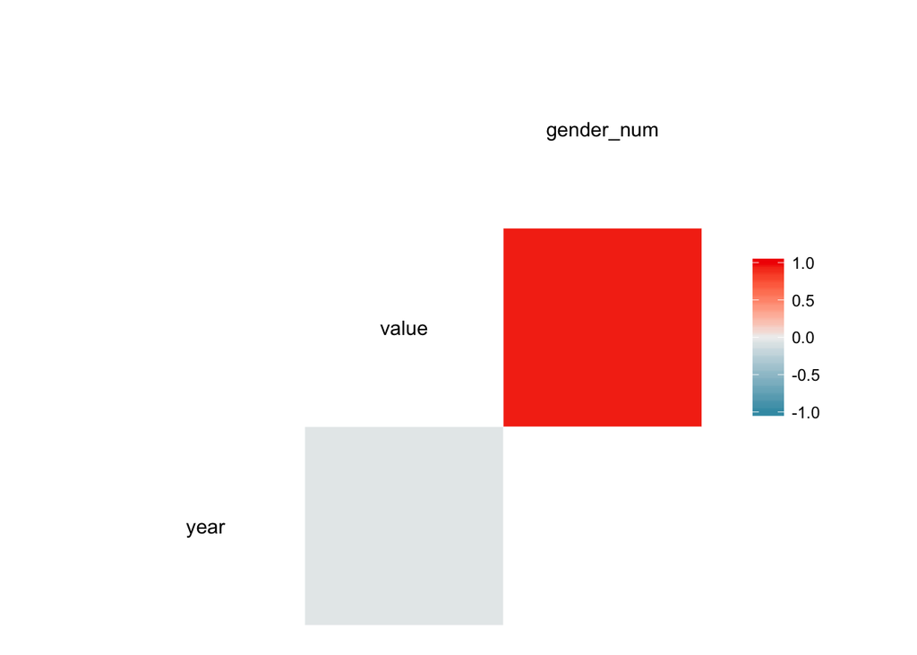

```r
#ggcorr for correlation coeeficient
install.packages("GGally")
library(GGally)
ggcorr(joint_unemployment_total)
```

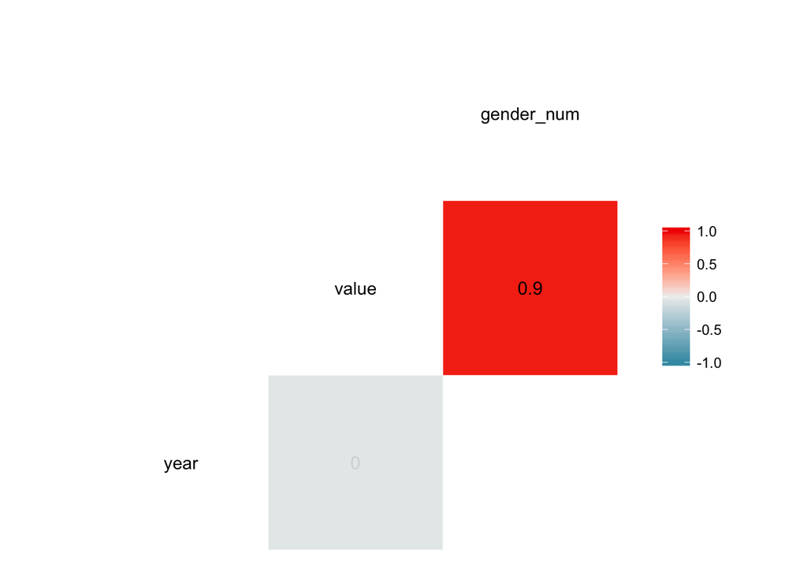

```r
# ggcorr with labels
ggcorr(joint_unemployment_total,
       label = TRUE,
       label_alpha = TRUE)
```

4. What does this visual representation of correlation coefficients tell you about your data? Are there any relationships (or lack thereof) that are surprising to you? Why or why not?

The data visualization of the correlation coeffcient says that there is strong correlation between gender_num and value variables (0.9), but the there is no relationship between year and other variables.

5. What are the limitations of correlation coefficients? Can they ever be misleading? If so, in what ways?

The correlation can be misleading in some ways. For instance, if the relationship is not linear, the correlation coeeficinet can not capter it and could give a number that does not reflect the reality.We should also keep in mind that correlation does not mean causation. Potential confounders may be barier to understand the reality. Sometimes correlations could be sporious, not real one.